# WK4｜Random Forests

Alyse Lin

2026-02-02

# Part 0｜你要先記住的一句話

**一句話總結：** Random Forest（random forest: many randomized trees + voting）=「很多棵不太一樣的決策樹一起投票」，所以比單棵樹更穩。

**你要背的 3 個重點：**

1. 決策樹很直覺，但容易不穩（high variance: sensitive to small data changes）
2. 森林用兩種隨機來做出「不太一樣的樹」（diversity: trees are different）
3. 不太一樣的樹一起投票，錯誤比較不會同時發生 → 整體更準、更穩

**最容易錯的 1 個地方：** - 以為「樹越多一定越好」。其實樹越多通常更穩，但會更慢；而且如果樹都很像，投票提升有限。

# 延伸資源- 快速了解內容

- [Gemini｜Random Forests（快速複習）](https://gemini.google.com/share/481481df72ae)
- [YouTube｜ 機器學習：一支影片搞懂 Random Forests 隨機森林：Bootstrap、自助抽樣、投票、OOB 一次搞懂](https://youtu.be/zue2r05Am24?si=6Pa4J5xJuKLIYkF2)
- [YouTube｜機器學習入門：隨機森林（Random Forest）其實就是「很多棵樹投票」](https://youtu.be/LcZwPWUwJWw?si=rZSl_bLjdAE3HDJd)

# Part 1｜資料與目標（老師 Colab Q0–Q2）

## 1.1 我們在解什麼問題？（分類）

這個作業是「分類（classification: predict a class label）」問題。

- **X（features: input columns）**：一堆你拿來做判斷的欄位，例如 Age、Cholesterol。
- **y（target/label: what to predict）**：你要預測的答案欄位；老師用 Diag（診斷）。

**超白話場景（Intuition story）** 你是醫師助理，你手上有： - 年齡、血壓、膽固醇、心電圖結果… 你要做的事是： - 猜這個人「有沒有心臟病」（0=沒有、1=有）

**小練習（Quick check）** Q：如果你的 y 是「身高」，那還是分類嗎？ A：不是。那是迴歸（regression: predict a numeric value）。

**一句話總結：** 這堂課先用分類當例子，因為最容易用 confusion matrix/recall 看出模型好不好。

**你要背的 3 個重點：**

1. X=輸入，y=要預測的答案
2. classification=預測類別（0/1）
3. 先把 y 變成二元，後面評估會更清楚

**最容易錯的 1 個地方：** - 把「特徵」和「標籤」搞反。

## 1.2 Q1 - 資料清理（Data cleaning）

老師提醒：sklearn 的樹模型在新版能處理 missing value（missing values: absent entries），但你的資料裡常見會有 `?` 這種字元，**你要先把它變成真正的缺失（NaN）**，不然模型會把它當成文字，直接炸掉。

你要做到三件事： 1. 把 `?` 變成 NaN 2. 讓欄位都變 numeric（numeric: numbers） 3. 把 Diag 轉成 binary（二元） - 0 → 0（negative class: no disease） - >0 → 1（positive class: disease）

**直覺：為什麼要做這些？ - 模型只吃得下「數字」 - 而且我們希望 y 是 0/1，這樣 recall（recall: TP/(TP+FN)）才好解釋

**可直接貼進 Colab 的 code（示範版）**

```python
import numpy as np
import pandas as pd

# 1) 讀資料（依你的 notebook 路徑調整）
df = pd.read_csv("heart.csv")

# 2) 把 '?' 變成 NaN
df = df.replace("?", np.nan)

# 3) 轉成數值（無法轉的會變 NaN）
for col in df.columns:
    df[col] = pd.to_numeric(df[col], errors="coerce")

# 4) Diag 二元化：0->0, >0->1
#    （假設 Diag 欄位存在）
df["Diag"] = (df["Diag"] > 0).astype(int)
```

**常見踩雷（Common pitfalls）** - 你只做了 `replace("?", np.nan)`，但沒 `to_numeric`： → 有些欄位還是 object，模型會報錯。

**小練習（Quick check）** Q：`errors="coerce"` 的意思是什麼？ A：轉不了就變 NaN（coerce: force invalid to NaN）。

**一句話總結：** 清理的目的就是把資料變成「模型吃得下」的乾淨數字。

**你要背的 3 個重點：**

1. `?` 不是 missing，NaN 才是 missing
2. 欄位要 numeric
3. y（Diag）轉 0/1，後面評估才清楚

**最容易錯的 1 個地方：** - 忘記把 y 二元化，導致你後面 confusion matrix/recall 解釋全亂掉。

## 1.3 Q2 - 切訓練/測試 + 固定亂數（train/test split + random seed）

關鍵字： - random_state / seed（random seed: makes results reproducible） - train/test split（split data into train/test: hold out data for evaluation）

**直覺（Intuition）** Random Forest 很多地方都會隨機： - 抽資料（bootstrap） - 抽特徵（max_features）

所以如果你不固定 random_state，你每次跑都不一樣，根本不知道自己到底學到什麼。

**可直接貼進 Colab 的 code（示範版）**

```python
from sklearn.model_selection import train_test_split

RS = 42

X = df.drop(columns=["Diag"])
y = df["Diag"]

X_train, X_test, y_train, y_test = train_test_split(
    X, y,
    test_size=0.2,
    random_state=RS,
    stratify=y,  # 分層抽樣：讓 train/test 的 0/1 比例接近
)
```

**小練習（Quick check）** Q：為什麼要 `stratify=y`？ A：避免剛好抽到「train 幾乎都 0、test 很多 1」這種不公平切法。

**一句話總結：** 固定 random_state 讓你能「重現結果」，stratify 讓切分更公平。

**你要背的 3 個重點：**

1. random_state=固定亂數
2. train 用來學，test 留到最後評估
3. stratify 讓 0/1 比例更平均

**最容易錯的 1 個地方：** - 一直用 test set 調參（這會讓 test 失去“最後考試”的意義）。

# Part 2｜Random Forest 到底 random 在哪裡？（老師 Colab Q3）

## 2.1 兩個 random：抽資料 + 抽特徵

Random Forest 的核心不是「神秘」，而是非常清楚的兩件事：

1. **bootstrap（bootstrapping: sample rows with replacement）**
   - 每棵樹都拿到一份「用有放回抽樣」抽出的訓練資料
2. **max_features（feature subsampling: only some features per split）**
   - 每次樹要做 split（split: choose a feature+threshold）時，不是看全部特徵，而是看一部分

## 2.2 看圖就懂：bootstrap + 投票

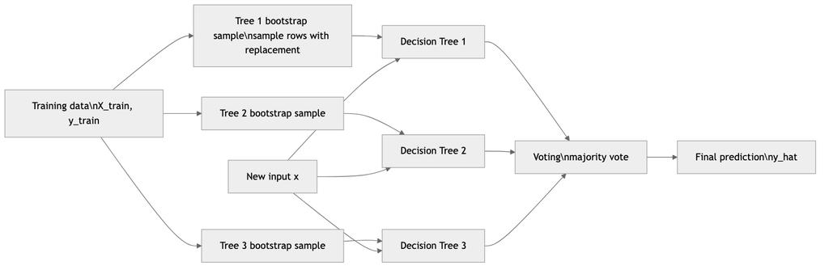

**直覺（Intuition｜白話解釋）** 你可以把每棵樹想成「一個朋友的意見」： - 每個朋友看的資料不太一樣（bootstrap） - 每個朋友思考時只看部分線索（max_features） 最後大家投票（voting）

### 為什麼要這樣做？（你一定要懂的原因）

如果每棵樹都一模一樣，投票就沒意義。

我們要的是： - 每棵樹都「有點不一樣」 - 但每棵樹也不要太爛

所以 random 的目的只有一個： > **讓樹彼此不太像（diversity），投票才能互相補洞。**

**小練習（Quick check）** Q：如果 `max_features` 設超大（每次 split 幾乎看全部特徵），會怎樣？ A：樹會變得很像 → 投票提升變小。

**一句話總結：** Random Forest 的 random 是為了做出「多樣化的樹」。

**你要背的 3 個重點：**

1. bootstrap=抽資料列
2. max_features=每次 split 抽特徵
3. 多樣化（diversity）讓投票有效

**最容易錯的 1 個地方：** - 只背名詞，不知道「為什麼要 random」。

# Part 3｜OOB：不用另外切 validation，也能「內建驗證」你的森林（老師 Colab Q5）

### 新手白話版：OOB 到底在幫你做什麼？（用一句話記）

- **OOB 就是 Random Forest 的「內建模擬考」**：不用另外切 validation，就能先估你模型大概會不會翻車。

### 你最需要懂的 3 句話

1. 每棵樹都用 bootstrap 抽資料 → 所以每棵樹「沒抽到」一部分訓練資料
2. 沒抽到的那部分資料，就是那棵樹的 OOB
3. 把每筆資料「由沒看過它的那些樹」來投票，就得到 OOB 預測 → 用來算 OOB recall

### 為什麼 OOB 通常比 training 低？（再白話一次）

- training：你讓學生寫「做過的考古題」
- OOB：你讓學生寫「沒做過的題目」

所以 OOB 比 training 低是正常，而且其實是好事：代表你在看比較接近真實的估計。

## 3.1 先用一句話把 OOB 講完

**一句話總結：** OOB（out-of-bag: rows not sampled for a tree）=「對某棵樹來說，它沒抽到的那些訓練資料」，可以拿來當那棵樹的『小考題』。

## 3.2 OOB 是怎麼來的？（你腦中要有畫面）

Random Forest 每棵樹都會做 bootstrap（bootstrapping: sample rows with replacement）。

這件事會自然產生兩種資料： - **in-bag**：被那棵樹抽到的資料（它用來學習） - **out-of-bag (OOB)**：沒被那棵樹抽到的資料（它用來測試）

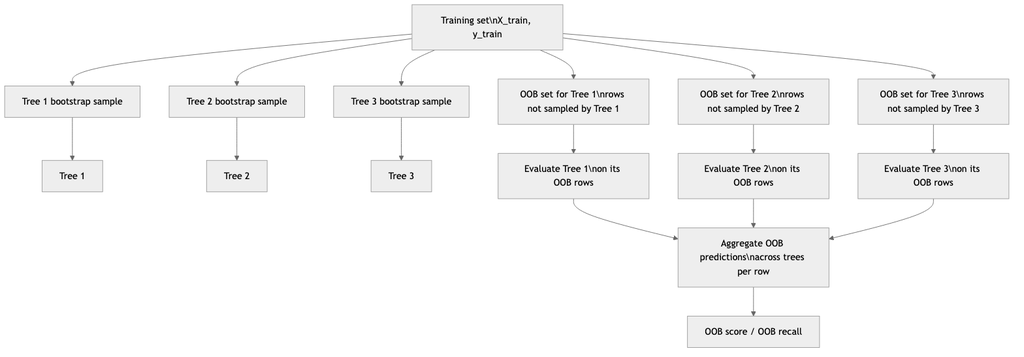

### 白話例子（小數字）

假設你的訓練集有 10 筆資料（1~10）。 Tree 1 bootstrap 抽 10 次（有放回），可能抽到： - 1, 1, 2, 4, 4, 4, 5, 7, 8, 10

那對 Tree 1 來說： - in-bag 可能是 {1,2,4,5,7,8,10} - OOB 可能是 {3,6,9}

Tree 1 沒看過 3/6/9，於是你就可以拿 3/6/9 來測 Tree 1。

## 3.3 為什麼 OOB 會像 validation？

你可以把 OOB 想成： - 每棵樹都自帶一份「沒看過的考卷」 - 森林整體也就能用這些 OOB 預測做一個「類 validation」的估計

關鍵字： - OOB score（oob_score: built-in generalization estimate） - OOB recall（oob recall: recall computed from OOB predictions）

## 3.4 你一定會被問的觀察：為什麼 OOB 通常比 training 低？（老師 Q5 的核心）

因為： - **training** 的評估：模型在「看過的資料」上算 → 通常偏樂觀 - **OOB** 的評估：更接近「沒看過的資料」 → 比較像真實泛化（generalization）→ 通常更低

用新手能懂的比喻： - training = 你背過的題目再考一次 - OOB = 沒背過的題目突然小考

所以 OOB 低是正常的，不是模型壞掉。

## 3.5 可直接貼進 Colab 的 code（OOB + recall）

```python
from sklearn.ensemble import RandomForestClassifier
from sklearn.metrics import recall_score

RS = 42

rf = RandomForestClassifier(
    n_estimators=300,
    max_depth=None,
    max_features="sqrt",
    oob_score=True,
    random_state=RS,
    n_jobs=-1,
)

rf.fit(X_train, y_train)

# 1) OOB score（sklearn 內建）
print("OOB score:", rf.oob_score_)

# 2) OOB 預測：用 oob_decision_function_ 轉成 class prediction
#    oob_decision_function_ 是每筆資料被 OOB 樹投票後的 class probability
proba_oob = rf.oob_decision_function_[:, 1]
y_pred_oob = (proba_oob >= 0.5).astype(int)

print("OOB recall:", recall_score(y_train, y_pred_oob))
```

### 你可能會問：為什麼是用 y_train 來算 OOB recall？

因為 OOB 是「在訓練集內部」做的驗證： - 這些 row 仍然屬於 training set - 只是『對某些樹來說』它們是沒看過的

## 3.6 常見踩雷（我幫你先避掉）

1. **忘記開 oob_score=True**
   - 就不會有 rf.oob_score_ / rf.oob_decision_function_
2. **用 test set 調參**
   - 正確順序：先用 OOB/CV 調參 → 最後才碰 test
3. **把 oob_score_ 當成 recall**
   - oob_score_ 預設是 accuracy（accuracy: fraction correct）
   - 你要 recall 要自己算（像上面那段）

## 3.7 小練習（含解答）

Q：如果你的資料正負類很不平衡（例如有病的人很少），為什麼你會更在意 recall？

A：因為你不想漏抓真正有病的人（FN 太多）。 Recall 高代表你漏掉的少。

**一句話總結：** OOB 幫你在不額外切 validation 的情況下，得到一個接近泛化的估計。

**你要背的 3 個重點：**

1. OOB = 對某棵樹沒抽到的訓練資料
2. OOB 通常比 training 低是正常（比較像沒看過的考卷）
3. oob_score_ 多半是 accuracy；要 recall 你要自己算

**最容易錯的 1 個地方：** - 把 oob_score_ 當成 recall，然後做出錯誤結論。

# Part 4｜Confusion Matrix + Recall：你怎麼知道模型到底「漏掉了誰」？

### 新手一定要會的「一秒判讀法」

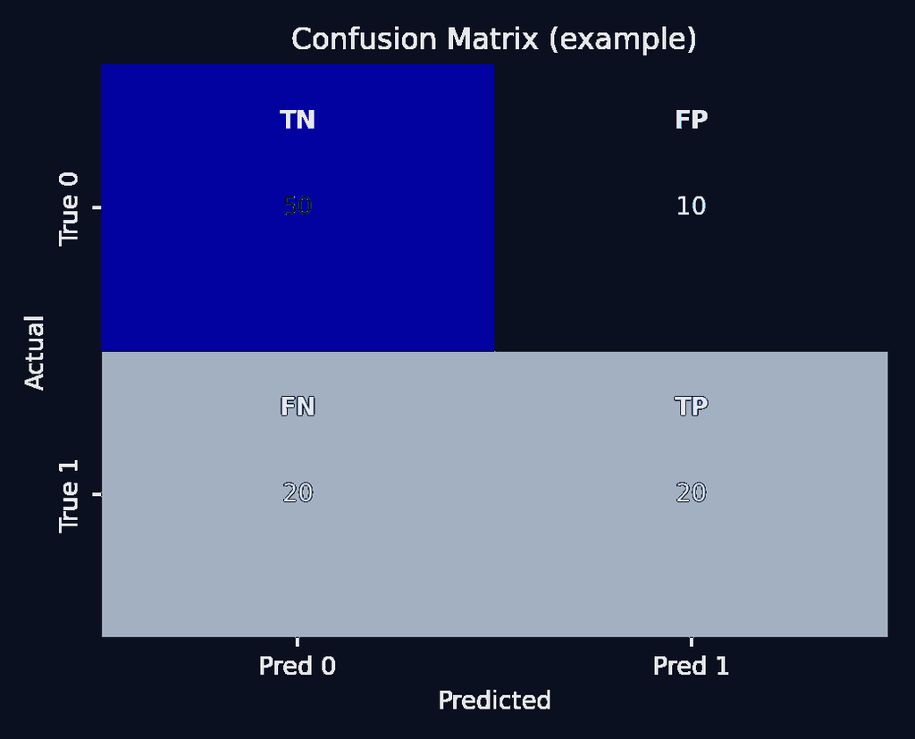

把混淆矩陣想成： - **列（row）= 真實答案** - **欄（col）= 你預測的答案**

所以： - 左上 = TN（真 0、判 0） - 右上 = FP（真 0、判 1） - 左下 = FN（真 1、判 0） - 右下 = TP（真 1、判 1）

### precision vs recall：最常搞混的差別（用一句話記）

- precision（precision: of predicted positives, how many are truly positive）= 「你說有病的人裡，真的有病的比例」→ 盯誤報 FP
- recall（recall/sensitivity: of true positives, how many you caught）= 「真的有病的人裡，你抓到多少」→ 盯漏報 FN

**醫療篩檢常更在意 recall**：漏掉病人（FN）通常成本更高。

### 小例子：同一個模型，調 threshold 會發生什麼？（概念版）

- threshold 變低：更容易判 1 → TP 可能增加、但 FP 也可能增加 → recall 往往上升、precision 往往下降
- threshold 變高：更嚴格判 1 → FP 可能下降、但 TP 也可能下降 → precision 往往上升、recall 往往下降

## 4.1 先用一句話把這章講完

**一句話總結：** 混淆矩陣（confusion matrix: table of TP/FP/FN/TN）就是把「你判對/判錯」拆成 4 種情況；而 recall（recall/sensitivity: TP/(TP+FN)）專門在乎「真正有病的人，你有沒有漏掉」。

## 4.2 你先把 4 個格子背起來（這是新手最常卡的）

先定義：我們把「有病」當作正類（positive class = 1）。

- **TP（true positive）**：真的有病（1），你也判有病（1） → 抓到了
- **FN（false negative）**：真的有病（1），你卻判沒病（0） → 漏掉（最危險）
- **FP（false positive）**：真的沒病（0），你卻判有病（1） → 誤報
- **TN（true negative）**：真的沒病（0），你也判沒病（0） → 判對

### 超白話比喻（你腦中要有畫面）

你在機場做安檢： - 正類（1）= 有帶危險物品 - FN = 有帶危險物品但你放他過 → 這就是你最不想發生的 所以很多安全/醫療情境會很在意 recall。

## 4.3 recall 是什麼？為什麼這堂課一直看它？

公式：

- **recall = TP / (TP + FN)**

白話： - 在「真的有病的人」裡，你抓到多少？

**你要背的重點：** - recall 越高 → 漏掉（FN）越少 - recall 不管你把多少健康的人誤報成有病（FP），它只在乎「有病的人有沒有被你漏掉」

> 這也是為什麼只看 accuracy（accuracy: fraction correct）很危險： 如果有病的人本來就很少，你就算全部猜「沒病」 accuracy 也可能很高，但其實你完全沒抓到病人。

## 4.4 用一個小例子讓你真的懂（不用怕）

假設測試集有 10 個人： - 真的有病：4 人 - 真的沒病：6 人

模型預測結果： - 抓到 3 個有病（TP=3） - 漏掉 1 個有病（FN=1）

那 recall = 3/(3+1) = 0.75

你看懂了嗎？它只看「4 個有病的人裡，你抓到幾個」。

## 4.5 可直接貼進 Colab 的 code（confusion matrix + recall）

```python
from sklearn.metrics import confusion_matrix, ConfusionMatrixDisplay, recall_score
import matplotlib.pyplot as plt

# 1) 用 test set 做預測
y_pred = rf.predict(X_test)

# 2) confusion matrix
cm = confusion_matrix(y_test, y_pred)
print(cm)  # [[TN FP]
           #  [FN TP]]

# 3) 畫出來（更直覺）
disp = ConfusionMatrixDisplay(confusion_matrix=cm, display_labels=[0, 1])
disp.plot(values_format='d')
plt.title('Confusion Matrix')
plt.show()

# 4) recall
print('Test recall:', recall_score(y_test, y_pred))
```

### 新手最常搞混的事（我直接幫你釘住）

1. `confusion_matrix` 的排列順序是：
   - 第一列：真實 0（negative）
   - 第二列：真實 1（positive）
   - 第一欄：預測 0
   - 第二欄：預測 1

所以印出來是：

- `[[TN, FP], [FN, TP]]`
2. 不要把 TP/FP/FN/TN 的英文背錯：
- True/False 指的是「你判對還判錯」
- Positive/Negative 指的是「你判成 1 還是 0」

## 4.6 小練習（含解答）

Q：如果你的 confusion matrix 是：

- TN=50, FP=10
- FN=20, TP=20

請問 recall 是多少？

A：recall = TP/(TP+FN) = 20/(20+20) = 0.5

**一句話總結：** Confusion matrix 把錯誤拆開看；recall 專門盯住「漏抓」這件事。

**你要背的 3 個重點：**

1. confusion matrix = [[TN FP],[FN TP]]
2. recall = TP/(TP+FN)
3. 醫療/安全情境通常更在意 FN（漏掉）

**最容易錯的 1 個地方：** - 把 confusion matrix 的格子位置看反，導致你算出錯的 recall。

# Part 5｜Q6 - validation_curve（調 n_estimators）— 樹變多到底在改善什麼？

### 新手白話：validation_curve 其實在回答 2 個問題

1. **這個參數從小到大，CV 表現會不會變好？**（有沒有必要加）
2. **training 跟 CV 差多少？**（gap 大不大，會不會過擬合）

### 你怎麼選 n_estimators（最穩的選法）

- 先找 CV 曲線「上升 → 趨於平坦」的拐點附近（飽和點）
- 在那附近選較小的 n_estimators（省時間、結果通常差不多）

### 常見誤解（直接避免）

- 「樹越多一定越準」：通常到某個點就飽和了，再加只是更慢
- 「gap 變小一定更好」：如果 train/CV 都很低，那是 underfitting，不是好

## 5.1 一句話先講完

**一句話總結：** validation_curve（validation curve: performance vs hyperparameter）就是「把超參數從小到大掃一遍」，同時畫出 training 表現與 cross-validation 表現，讓你看出：樹數變多時，模型是變好、變穩，還是只是更會背書。

## 5.2 你要看的不是“最高點”，而是 3 件事

你看圖時，請只盯這三件：

1. **CV 表現（cross-validation score）是不是上升後趨於平坦？**
   - 如果已經平坦，再加樹通常只會更慢，提升很小。
2. **training vs CV 的差距（gap）大不大？**
   - gap 大：可能有過擬合（overfitting: fits training too well）
   - gap 小：通常更穩，但也可能代表模型太弱（underfitting）
3. **曲線是不是很抖？**
   - 很抖代表不穩（variance 高），樹數增加通常會讓曲線更平滑、更穩。

## 5.3 超白話直覺：n_estimators 變大會發生什麼？

- n_estimators（number of trees）小：投票人少 → 結果容易受某幾棵樹影響 → 不穩
- n_estimators 大：投票人多 → 平均掉運氣 → 通常更穩

重要提醒： - 樹變多通常 **不太會讓模型更“複雜”到爆炸過擬合**（跟把 max_depth 拉很深不一樣），它多半改善的是「穩定性」。

## 5.4 可直接貼進 Colab 的 code（validation_curve + recall）

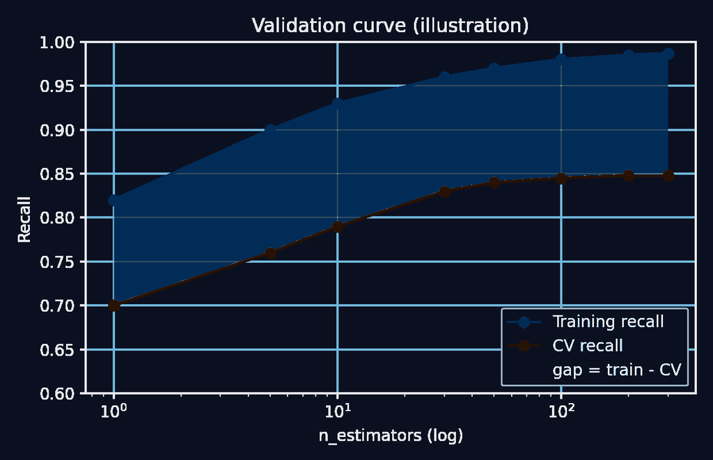

```python
import numpy as np
import matplotlib.pyplot as plt

from sklearn.ensemble import RandomForestClassifier
from sklearn.model_selection import validation_curve
from sklearn.metrics import make_scorer, recall_score

RS = 42

# 你要掃的樹數（可依老師 notebook 調整）
param_range = [1, 5, 10, 30, 50, 100, 200, 300]

rf = RandomForestClassifier(
    max_depth=None,
    max_features="sqrt",
    oob_score=True,
    random_state=RS,
    n_jobs=-1,
)

# 用 recall 當評分：我們關心漏抓病人（FN）
scorer = make_scorer(recall_score)

train_scores, valid_scores = validation_curve(
    rf,
    X_train,
    y_train,
    param_name="n_estimators",
    param_range=param_range,
    cv=5,
    scoring=scorer,
)

train_mean = train_scores.mean(axis=1)
train_std  = train_scores.std(axis=1)
valid_mean = valid_scores.mean(axis=1)
valid_std  = valid_scores.std(axis=1)

plt.figure(figsize=(8,5))
plt.plot(param_range, train_mean, marker='o', label='Training recall')
plt.fill_between(param_range, train_mean-train_std, train_mean+train_std, alpha=0.15)

plt.plot(param_range, valid_mean, marker='o', label='CV recall')
plt.fill_between(param_range, valid_mean-valid_std, valid_mean+valid_std, alpha=0.15)

plt.xscale('log')
plt.xlabel('n_estimators (log scale)')
plt.ylabel('Recall')
plt.title('Validation Curve: n_estimators vs Recall')
plt.legend()
plt.grid(True, alpha=0.3)
plt.show()
```

### 新手常見踩雷

1. **忘記用 log scale**：小樹數跟大樹數差很多，用 log 更容易看趨勢。
2. **只看 training 曲線**：training 幾乎都會很高，重點是 CV。
3. **把 recall 換成 accuracy 卻沒發現**：accuracy 可能會騙你（不平衡資料尤其危險）。

## 5.5 小練習（含解答）

Q：如果你看到「training recall 一直很高，但 CV recall 一直很低」，你會懷疑什麼？

A：可能過擬合（overfitting），或資料處理/切分有問題；也可能是模型參數（例如 max_depth 太深）讓樹太會背。

**一句話總結：** validation_curve 讓你用圖把「穩定性 vs 過擬合」看清楚。

**你要背的 3 個重點：**

1. 看 CV 曲線是否趨於平坦（飽和點）
2. 看 gap 判斷是否過擬合
3. n_estimators 主要改善穩定性（variance），不是一味增加複雜度

**最容易錯的 1 個地方：** - 只挑最高點，忽略「附近一片都不錯」才代表穩。

# Part 6｜Q7 - gap 趨勢— 樹變多時「訓練 vs CV」差距會怎麼變？

## 6.1 一句話先講完

**一句話總結：** gap = training 表現 − CV 表現；樹變多（n_estimators ↑）通常會讓結果更穩、CV 曲線更平滑，gap 多半會「縮小或趨於穩定」，而不是一直飄來飄去。

## 6.2 什麼是 gap？你要怎麼讀它？

- training recall：模型在訓練集上的召回率
- CV recall：模型在交叉驗證（cross-validation: repeated holdout folds）上的召回率

定義： - **gap = training recall − CV recall**

直覺： - gap 大：可能過擬合（overfitting）或模型不穩 - gap 小：通常更可靠；但也可能模型太弱（underfitting）

## 6.3 為什麼 n_estimators ↑ 通常會讓 gap 變得更可控？

Random Forest 的投票本質是「平均化」： - 樹少：運氣成分大（抽樣抽到什麼、某棵樹剛好很偏）→ 表現容易跳 - 樹多：平均掉單棵樹的偏差 → CV 表現更穩、方差更低（lower variance）

所以你常會看到： - training 曲線：很快就高（甚至飽和） - CV 曲線：慢慢上升後趨於平坦 - gap：一開始可能偏大，後來縮小或穩定

## 6.4 你在圖上該做的事（老師要你觀察的重點）

請你把你 Q6 畫出來的 validation curve 拿來做這件事：

1. 先算出每個 n_estimators 的 gap
2. 畫一條 gap 曲線（或直接印表）
3. 找到「gap 已經不再明顯改善」的區間 → 那裡通常就是樹數的合理選擇

## 6.5 可直接貼進 Colab 的 code（計算並畫 gap）

```python
import numpy as np
import matplotlib.pyplot as plt

# 假設你已經有：param_range, train_scores, valid_scores
train_mean = train_scores.mean(axis=1)
valid_mean = valid_scores.mean(axis=1)

gap = train_mean - valid_mean

for n, g in zip(param_range, gap):
    print(f"n_estimators={n:>4} | gap={g:.3f}")

plt.figure(figsize=(7,4))
plt.plot(param_range, gap, marker='o')
plt.xscale('log')
plt.xlabel('n_estimators (log scale)')
plt.ylabel('gap = train - CV')
plt.title('Gap trend vs n_estimators')
plt.grid(True, alpha=0.3)
plt.show()
```

## 6.6 常見踩雷（新手很容易誤判）

1. **gap 變小 ≠ 一定更好**
   - 如果 train 跟 CV 都很低，gap 也會很小，但那是 underfitting。
2. **只看 gap，不看 CV 的高度**
   - 正確看法：先確保 CV 夠高，再看 gap 是否合理。
3. **樹數加到很大但 CV 早就平了**
   - 這只是讓你更慢，不會讓你更準。

## 6.7 小練習（含解答）

Q：如果你發現 n_estimators 從 100 → 300 時，CV recall 幾乎不再上升，但訓練時間增加很多，你會怎麼選？

A：選接近飽和點的樹數（例如 100 或 200），因為之後是「花很多時間換很小提升」。

**一句話總結：** Q7 要你用 gap 把「穩定性」量化，看出樹數何時已經夠了。

**你要背的 3 個重點：**

1. gap = train − CV
2. 樹變多通常讓 CV 更穩、gap 更可控
3. 選參數要看：CV 高度 + gap + 計算成本

**最容易錯的 1 個地方：** - 只看 gap 很小就以為好，卻沒發現 CV 其實也很低（模型太弱）。

# Part 7｜Q8 - Heatmap 選參數— n_estimators × max_depth 怎麼挑「穩定又不會太慢」？

### 新手白話：heatmap 就是「一次看很多組參數」

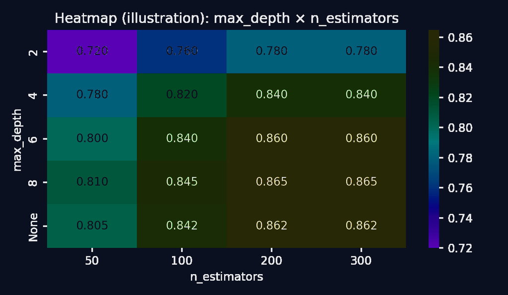

你可以把它想成： - 每一格 = 一組（max_depth, n_estimators） - 顏色越深 = CV recall 越高

### 你要怎麼挑：3 步驟（最實用）

1. 先找深色區域（高 recall）
2. 從深色區域挑「max_depth 不要太深」的那一列（更不容易過擬合）
3. 再選「n_estimators 不要太大」的那一欄（更快）

### 一個很重要的取捨觀念

- 你不是在找「最高分」，你是在找「高分 + 穩定 + 夠快」
- 所以“附近一片都好”通常比“孤零零最高的一格”更值得選

## 7.1 一句話先講完

**一句話總結：** heatmap（heatmap: color map of scores）就是把「很多組參數」的 CV recall 用顏色畫成一張圖；你要找的通常不是“最高一個點”，而是「附近一整片都不錯」的穩定區（stable region）。

## 7.2 你先理解兩個參數在控制什麼

- n_estimators（number of trees）
  - 越大通常越穩（variance 下降），但越慢
- max_depth（maximum depth）
  - 越深：單棵樹越會切得很細 → 訓練表現可能更高
  - 但太深容易過擬合（overfitting）或讓模型更不穩

**超白話：** - n_estimators = 投票人數 - max_depth = 每個投票人的「規則複雜度」

## 7.3 你看 heatmap 要用的選法（新手也不會選錯）

請照這個順序挑：

1. **先找 CV recall 的高區（顏色最深的那一帶）**
2. 在高區裡面，優先選 **max_depth 不要過深**（避免過擬合、也更可解釋）
3. 在 max_depth 合理的前提下，選 **n_estimators 不要過大**（避免太慢）
4. 最佳選擇通常是：
   - 「附近一片都好」
   - 「再往右/往下也不會再明顯變好」

## 7.4 可直接貼進 Colab 的 code（掃參數 + 畫 heatmap）

```python
import numpy as np
import pandas as pd
import matplotlib.pyplot as plt
import seaborn as sns

from sklearn.ensemble import RandomForestClassifier
from sklearn.model_selection import cross_val_score
from sklearn.metrics import make_scorer, recall_score

RS = 42
scorer = make_scorer(recall_score)

n_list = [50, 100, 200, 300]
d_list = [2, 4, 6, 8, None]  # None = 不限制深度

rows = []
for d in d_list:
    for n in n_list:
        rf = RandomForestClassifier(
            n_estimators=n,
            max_depth=d,
            max_features="sqrt",
            oob_score=True,
            random_state=RS,
            n_jobs=-1,
        )
        scores = cross_val_score(rf, X_train, y_train, cv=5, scoring=scorer)
        rows.append({
            "max_depth": str(d),
            "n_estimators": n,
            "cv_recall_mean": scores.mean(),
        })

df_grid = pd.DataFrame(rows)
pivot = df_grid.pivot(index="max_depth", columns="n_estimators", values="cv_recall_mean")

plt.figure(figsize=(8,4))
sns.heatmap(pivot, annot=True, fmt=".3f", cmap="viridis")
plt.title("CV Recall heatmap: max_depth × n_estimators")
plt.xlabel("n_estimators")
plt.ylabel("max_depth")
plt.show()
```

### 你可能會遇到的小細節

- `max_depth=None` 代表不限制深度，通常比較容易 overfit（視資料而定）。
- 如果你覺得跑太慢：
  - 把 n_list/d_list 減少
  - 或先用較粗的 grid 找到好區域，再細掃。

## 7.5 小練習（含解答）

Q：如果你看到 heatmap 顯示： - max_depth=8, n_estimators=300 的 recall 最高 - 但 max_depth=6, n_estimators=200 也幾乎一樣高 你會選哪個？

A：通常選 **max_depth=6, n_estimators=200**。 原因：更快、較不容易過擬合，而且表現幾乎一樣（這就是「穩定區」的概念）。

**一句話總結：** Q8 要你學會用 heatmap 做「取捨」，不是只追最高分。

**你要背的 3 個重點：**

1. heatmap 看的是「一片穩定區」
2. max_depth 太深容易過擬合
3. n_estimators 太大會很慢，找飽和點就好

**最容易錯的 1 個地方：** - 只挑最高那一格，結果變慢、變不穩，實際泛化沒有更好。

# Part 8｜Q9 - rf_final（最後模型）— 用你選的參數訓練，並把結果都印出來

## 8.1 一句話先講完

**一句話總結：** Q9 就是把你在 Q8 heatmap 選到的那組參數，真的拿來訓練一個最後模型 rf_final，然後用同一套指標（尤其 recall）把 train / OOB / test 都算出來，確認你的模型不是只在訓練集好看。

## 8.2 你要先決定：你選的參數是哪一組？

你在 Q8 heatmap 應該會挑到一組「穩定區」的參數，例如： - n_estimators = 200 - max_depth = 6 （這只是示例，你要用你自己 heatmap 的選擇）

我建議你記錄成兩個變數，避免你後面改來改去搞混：

```python
N_FINAL = 200
D_FINAL = 6
```

## 8.3 可直接貼進 Colab 的 code（訓練 rf_final + 三種評估）

```python
import numpy as np
import matplotlib.pyplot as plt

from sklearn.ensemble import RandomForestClassifier
from sklearn.metrics import recall_score, confusion_matrix, ConfusionMatrixDisplay

RS = 42

# 你從 Q8 選到的參數（請用你自己的）
N_FINAL = 200
D_FINAL = 6

rf_final = RandomForestClassifier(
    n_estimators=N_FINAL,
    max_depth=D_FINAL,
    max_features="sqrt",
    oob_score=True,
    random_state=RS,
    n_jobs=-1,
)

rf_final.fit(X_train, y_train)

# ---------
# 1) Training recall
# ---------
y_pred_train = rf_final.predict(X_train)
train_recall = recall_score(y_train, y_pred_train)

# ---------
# 2) OOB recall
# ---------
# oob_decision_function_: (n_samples, n_classes) probabilities aggregated from OOB trees
proba_oob = rf_final.oob_decision_function_[:, 1]
y_pred_oob = (proba_oob >= 0.5).astype(int)
oob_recall = recall_score(y_train, y_pred_oob)

# ---------
# 3) Test recall
# ---------
y_pred_test = rf_final.predict(X_test)
test_recall = recall_score(y_test, y_pred_test)

print("=== rf_final summary ===")
print("params:", {"n_estimators": N_FINAL, "max_depth": D_FINAL, "max_features": "sqrt"})
print("OOB score (accuracy):", rf_final.oob_score_)
print("Train recall:", train_recall)
print("OOB recall:", oob_recall)
print("Test recall:", test_recall)

# Confusion matrix on test
cm = confusion_matrix(y_test, y_pred_test)
disp = ConfusionMatrixDisplay(confusion_matrix=cm, display_labels=[0, 1])
disp.plot(values_format='d')
plt.title('rf_final — Confusion Matrix (test)')
plt.show()
```

## 8.4 你要怎麼解讀結果？（新手不會迷路版）

你會得到三個 recall： - **Train recall**：模型在「看過的訓練資料」的召回率 - **OOB recall**：模型在「訓練集內部的類驗證（內建小考）」的召回率 - **Test recall**：模型在「真正最後考試（test set）」的召回率

### 正常的情況（你看到這樣就放心）

- Train recall 通常最高
- OOB recall 比 train 低一些
- Test recall 接近 OOB recall（或在附近波動）

### 不正常的警訊（你看到這樣就要調參/檢查資料）

1. Train 很高，但 OOB/Test 很低
   - 可能過擬合（max_depth 太深常見）
2. 三個都很低
   - 模型太弱（underfitting）或資料訊號本來就弱
3. Test 明顯比 OOB 高很多
   - 可能只是剛好 split 很幸運（lucky split）
   - 或 test 很小、波動大

## 8.5 小練習（含解答）

Q：如果你看到 train recall=0.98，但 oob recall=0.60、test recall=0.58，你會先調哪個參數？

A：先懷疑 max_depth 太深（樹太會背）。你可以先把 max_depth 降低，或限制 min_samples_leaf。

**一句話總結：** Q9 是把「選參數」落地成 rf_final，並用 train/OOB/test 三段式檢查泛化。

**你要背的 3 個重點：**

1. rf_final 用你在 Q8 選到的參數
2. OOB 是內建驗證，常常比 training 低
3. 最重要是 test 是否接近 OOB（代表比較可靠）

**最容易錯的 1 個地方：** - 只看 training recall 很高就以為成功，卻沒看 OOB/test。

# Part 9｜Q10 - 為什麼 OOB recall 接近 test recall 是好消息？（泛化可信度）

## 9.1 一句話先講完

**一句話總結：** 如果 OOB recall 跟 test recall 很接近，通常代表你的模型表現不是「剛好運氣好」；OOB 這個內建驗證估計在你的資料上是可信的。

## 9.2 你要先把三個 recall 的角色記住

- **Train recall**：看過的題目 → 通常偏樂觀
- **OOB recall**：訓練集內建小考（類 validation）→ 通常更接近真實
- **Test recall**：最後考試（你最在乎）

## 9.3 為什麼 OOB ≈ test 代表比較可靠？

因為 OOB 的本質是： - 每筆訓練資料只用「沒看過它的那些樹」來預測 - 所以它更像是在模擬「模型遇到新資料」的狀態

如果你看到： - OOB recall ≈ test recall 代表： - 你用 OOB 做的調參/評估，大方向沒有偏掉 - test set 的結果也比較像真實泛化，而不是抽樣巧合

## 9.4 什麼情況下 OOB 可能跟 test 差很多？（你要知道例外）

1. **test set 太小**
- 小測試集波動大（variance 大），一次切分就可能差很多。
2. **資料分佈不一致（distribution shift）**
- train/test 來源不一樣，OOB 估的是「訓練分佈內」的泛化，test 卻是另一種分佈。
3. **資料洩漏（data leakage）**
- 你不小心把答案訊息漏到特徵裡，train/OOB 會假好看，test 可能突然掉。

## 9.5 可直接貼進 Colab 的小檢查（把三個 recall 放在一起看）

```python
print('Train recall:', train_recall)
print('OOB recall:  ', oob_recall)
print('Test recall: ', test_recall)

# 粗略判斷：OOB 和 test 的差距
print('abs(OOB - Test):', abs(oob_recall - test_recall))
```

你不用追求「完全一樣」，接近就好。

## 9.6 小練習（含解答）

Q：如果你的 OOB recall = 0.72，test recall = 0.70，你會怎麼解讀？

A：這是好現象，代表 OOB 估計大致可信，test 結果不是剛好幸運。

**一句話總結：** OOB ≈ test 通常代表你的泛化評估比較可靠。

**你要背的 3 個重點：**

1. Train 偏樂觀、OOB 更像 validation、Test 是最後考試
2. OOB ≈ Test → 估計可信
3. 差很多要懷疑：test 太小 / 分佈不同 / leakage

**最容易錯的 1 個地方：** - 看到 OOB 跟 test 不一樣就慌，其實小差距是正常波動。

# Part 10｜Q11 - Feature importance（重要性）+ permutation importance（置換重要性）— 你要會解讀、也要會懷疑

### 新手白話：importance 是「模型用什麼線索」，不是「世界真相」

- 模型可以把「相關」當作線索，但相關不等於因果。

### 什麼時候你會“解讀錯”？（最常見 3 種）

1. 把重要性當因果
2. 忽略特徵相關性（A、B 其實同一件事）
3. 只看 top1，就說其他都不重要（其實可能是很多小貢獻加總）

### 你怎麼用這個結果來幫助學習？

- 把前 5–10 名特徵當作「你回頭要查清楚意義」的清單
- 用它來設計下一步：你要收集更可靠的特徵？或做更好的資料清理？

## 10.1 一句話先講完

**一句話總結：** feature importance（feature importance: how much a feature helps the model）告訴你模型「常用哪些特徵來做判斷」；permutation importance（permutation importance: shuffle one feature and see performance drop）更像是在問「如果把某特徵的資訊打亂，模型會變爛多少？」

## 10.2 先講一個超重要觀念（新手最常誤會）

- **重要性 ≠ 因果（importance ≠ causality）**
  - 重要性高不代表它「造成」心臟病，只代表模型用它來預測很有幫助。
- **root（根節點）不一定是最重要特徵**
  - root 只是一棵樹的一個早期決策
  - 重要性是整座森林「累積」的貢獻

## 10.3 兩種常見重要性：你要知道差別

### (A) impurity-based importance（樹模型內建的重要性）

- 直覺：看這個特徵在分裂時，讓資料變「更乾淨」的貢獻（impurity decrease）。
- 優點：快、內建
- 缺點：對某些型態的特徵可能偏好（例如可分裂點很多的連續特徵）

### (B) permutation importance（置換重要性）

- 直覺：把某特徵的值打亂 → 模型如果變爛很多 → 表示它很重要
- 優點：比較直觀、比較像「拿走資訊」的實驗
- 缺點：特徵高度相關時（correlated features），打亂其中一個可能不會掉很多（因為另一個特徵補上了）

## 10.4 可直接貼進 Colab 的 code（rf_final 的兩種重要性）

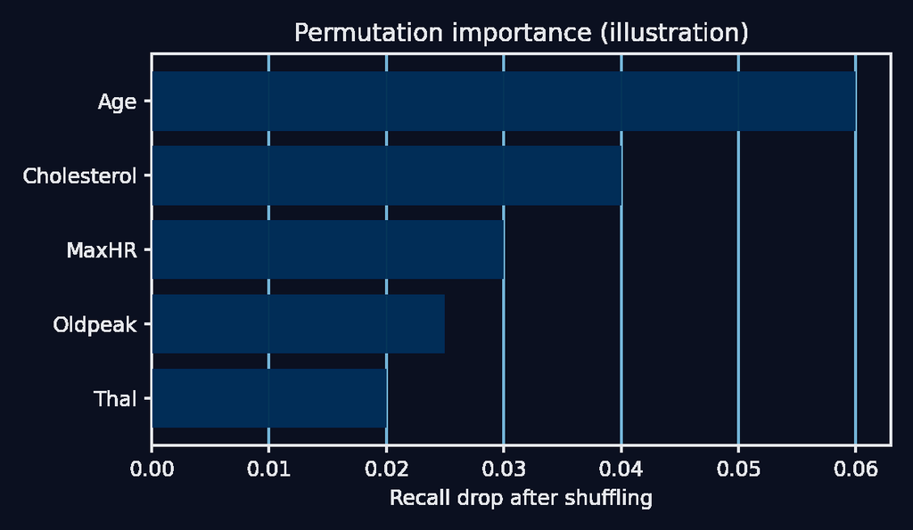

```python
import numpy as np
import pandas as pd
import matplotlib.pyplot as plt

from sklearn.inspection import permutation_importance
from sklearn.metrics import make_scorer, recall_score

# (1) 內建 importance
imp = pd.Series(rf_final.feature_importances_, index=X_train.columns)
imp = imp.sort_values(ascending=False)
print('Top features (impurity-based):')
print(imp.head(15))

plt.figure(figsize=(7,5))
imp.head(15).sort_values().plot(kind='barh')
plt.title('Feature importance (impurity-based)')
plt.xlabel('importance')
plt.show()

# (2) permutation importance：用 test set 更合理
scorer = make_scorer(recall_score)
perm = permutation_importance(
    rf_final,
    X_test,
    y_test,
    n_repeats=10,
    random_state=42,
    scoring=scorer,
)

perm_imp = pd.Series(perm.importances_mean, index=X_test.columns).sort_values(ascending=False)
print('Top features (permutation importance, by recall drop):')
print(perm_imp.head(15))

plt.figure(figsize=(7,5))
perm_imp.head(15).sort_values().plot(kind='barh')
plt.title('Permutation importance (by recall)')
plt.xlabel('mean importance')
plt.show()
```

## 10.5 常見踩雷

1. **拿 importance 去做因果解釋**
2. **只看一種 importance 就下結論**
3. **特徵高度相關時，permutation importance 會“分散功勞”**

## 10.6 小練習（含解答）

Q：如果 A、B 兩個特徵高度相關（幾乎代表同一件事），為什麼 permutation importance 可能顯示兩者都不高？

A：因為你打亂 A 時，B 還能補上資訊；打亂 B 時，A 還能補上資訊，所以單獨打亂一個掉分不大。

**一句話總結：** 重要性是「模型怎麼用資料」，不是「世界的因果」。

**你要背的 3 個重點：**

1. importance ≠ causality
2. impurity-based vs permutation importance 的差別
3. correlated features 會影響解讀

**最容易錯的 1 個地方：** - 把“重要”誤解成“造成”。

# Part 11｜Q12 - 把 rf_final 的結果整理成「一頁總表」（你交作業/複習用）

**一句話總結：** 你要能用一頁把模型說清楚：參數、train/OOB/test recall、test confusion matrix、以及最重要特徵。

### 建議你輸出的 5 行（可直接貼 Colab）

```python
print('params:', rf_final.get_params())
print('Train recall:', train_recall)
print('OOB recall:  ', oob_recall)
print('Test recall: ', test_recall)
print('OOB score (accuracy):', rf_final.oob_score_)
```

再加上： - test confusion matrix 圖 - permutation importance 前 10 名

# Part 12｜Q13 - 你要會回答「這個模型可靠嗎？」（限制與改進）

**一句話總結：** 可靠 = 不只在 train 好看，而是 OOB/test 也穩；改進方向通常是：資料處理、調參、以及評估方式。

你可以從 4 個角度講： 1. 資料量與不平衡（imbalanced data） 2. 過擬合/欠擬合（max_depth、min_samples_leaf） 3. 評估指標是否合理（recall vs precision） 4. 分佈是否一致（distribution shift）

# Part 13｜Q14 - 考點清單（Exam checklist｜可直接背版本）

## 1) 用白話說出 RF 的兩個 random（bootstrap + max_features）

**答案：** - Random Forest 的「random」主要來自兩件事： 1. **Bootstrap rows**：每棵樹用「有放回抽樣」抽出不同訓練資料（bagging） 2. **Feature subsampling (`max_features`)**：每次 split 只看一部分特徵，讓樹彼此更不一樣（diversity）

**關鍵字：** bootstrap / bagging / max_features / diversity / variance reduction

## 2) 解釋 OOB 是什麼、為什麼像 validation

**答案：** - **OOB (Out-of-Bag)** = 對某棵樹來說「沒被 bootstrap 抽到的樣本」。 - 因為這些 OOB 樣本「那棵樹沒看過」，所以把它拿來評估就像一個 **validation-like** 的泛化估計；通常比 training 分數低、更接近 test。

**關鍵字：** OOB / unseen samples / validation-like / generalization

## 3) 看懂 confusion matrix，並算出 recall

**答案：** - confusion matrix： - True 1 & Predict 1 = **TP** - True 1 & Predict 0 = **FN**（漏診，醫療常最痛） - **Recall (TPR)** = **TP / (TP + FN)**

**關鍵字：** confusion matrix / TP FN FP TN / recall / TPR / sensitivity

## 4) 用 validation_curve 解釋 n_estimators 增加時的變化與 gap

**答案：** - `n_estimators` 增加（樹更多）通常會讓模型 **更穩**： - training recall 可能小幅上升或趨於平穩 - CV recall 通常上升後趨於平台（plateau） - **gap（train − CV）** 常見會變小或趨穩：因為投票平均掉單棵樹的高變異（variance）。

**關鍵字：** validation curve / n_estimators / plateau / gap / variance

## 5) 用 heatmap 選一組「穩定區」參數

**答案：** - 看 heatmap 先找「大片顏色接近且偏高」的區域（stable region），不要只挑單一尖峰。 - 在穩定區裡： - 選較小 `max_depth` 往往更可解釋、較不 overfit - 選足夠的 `n_estimators` 讓表現進入 plateau（再加樹收益很小）

**關鍵字：** heatmap / stable region / max_depth / n_estimators / overfitting

## 6) 解釋 feature importance 與 permutation importance，且知道重要性≠因果

**答案：** - **Feature importance（impurity-based）**：看某特徵在訓練中帶來多少 impurity reduction（常偏好高基數/連續特徵）。 - **Permutation importance**：把某特徵打亂（shuffle），看模型表現掉多少；比較像「模型依賴度」的測試。 - 但不管哪種 importance：**重要性 ≠ 因果（importance ≠ causality）**，只能說模型用它，不能說它造成結果。

**關鍵字：** impurity-based importance / permutation importance / shuffle / model reliance / importance≠causality